# Vendas

DADOS OBTIDOS ATRAVES DO SITE https://www.kaggle.com/datasets/umairhayat/pizza-data-set-order-detail/data.

IMPORTANDO AS BIBLIOTECAS:

1 - PANDAS PARA MANIPULAÇÃO DOS DADOS

2 - MATPLOTLIB E SEABORN PARA VISUALIZAÇÃO DOS DADOS COM GRAFICOS

```python
import pandas as pd
import matplotlib.pyplot as plt
import seaborn as sns
```

Carregando os Databases

```python
OrdemPizza = pd.read_csv("order_details.csv")
DataPizza = pd.read_csv("orders.csv")
TipoPizza = pd.read_csv("pizza_types.csv", encoding='unicode_escape')
DadosPizza = pd.read_csv("pizzas.csv")
```

Iniciando o carregamento do Database, o Primeiro DataFrame a ser Manipulado é o de Ordem das Pizzas

Gerando estatísticas descritivas do Dataframe

```python
OrdemPizza.describe()
```

|  | order_details_id | order_id | quantity |
| --- | --- | --- | --- |
| count | 48620.000000 | 48620.000000 | 48620.000000 |
| mean | 24310.500000 | 10701.479761 | 1.019622 |
| std | 14035.529381 | 6180.119770 | 0.143077 |
| min | 1.000000 | 1.000000 | 1.000000 |
| 25% | 12155.750000 | 5337.000000 | 1.000000 |
| 50% | 24310.500000 | 10682.500000 | 1.000000 |
| 75% | 36465.250000 | 16100.000000 | 1.000000 |
| max | 48620.000000 | 21350.000000 | 4.000000 |

Verificando se existe alguma coluna com valores ausentes

```python
OrdemPizza.isna().sum()
```

```
order_details_id    0
order_id            0
pizza_id            0
quantity            0
dtype: int64
```

Ordenando em um grupo, os Maiores valores das pizzas pela quantidade total vendida em ordem decrescente

```python
OrdemPizza.groupby("pizza_id").sum().sort_values("quantity",ascending=False).head(5)
```

| pizza_id | order_details_id | order_id | quantity |
| --- | --- | --- | --- |
| big_meat_s | 44373219 | 19533329 | 1914 |
| thai_ckn_l | 34070922 | 14996768 | 1410 |
| five_cheese_l | 31911486 | 14048981 | 1409 |
| four_cheese_l | 31048657 | 13666613 | 1316 |
| classic_dlx_m | 29074088 | 12799554 | 1181 |

```
CARREGANDO O DATAFRAME DAS DATAS DO PEDIDO
```

```python
DataPizza
```

|  | order_id | date | time |
| --- | --- | --- | --- |
| 0 | 1 | 2015-01-01 | 11:38:36 |
| 1 | 2 | 2015-01-01 | 11:57:40 |
| 2 | 3 | 2015-01-01 | 12:12:28 |
| 3 | 4 | 2015-01-01 | 12:16:31 |
| 4 | 5 | 2015-01-01 | 12:21:30 |
| ... | ... | ... | ... |
| 21345 | 21346 | 2015-12-31 | 20:51:07 |
| 21346 | 21347 | 2015-12-31 | 21:14:37 |
| 21347 | 21348 | 2015-12-31 | 21:23:10 |
| 21348 | 21349 | 2015-12-31 | 22:09:54 |
| 21349 | 21350 | 2015-12-31 | 23:02:05 |

21350 rows × 3 columns

Gerando estatísticas descritivas do Dataframe

```python
DataPizza.describe()
```

|  | order_id |
| --- | --- |
| count | 21350.000000 |
| mean | 10675.500000 |
| std | 6163.358459 |
| min | 1.000000 |
| 25% | 5338.250000 |
| 50% | 10675.500000 |
| 75% | 16012.750000 |
| max | 21350.000000 |

Verificando se existe alguma coluna com valores ausentes

```python
DataPizza.isna().sum()
```

```
order_id    0
date        0
time        0
dtype: int64
```

Filtragem Do DataFrame com base no valor da coluna Id da Ordem com a Data do pedido

```python
DataPizza['date'][DataPizza['order_id']==21350]
```

```
21349    2015-12-31
Name: date, dtype: object
```

Contando a frequência de cada valor único na Coluna Order_id

```python
DataPizza['order_id'].value_counts()
```

```
order_id
1        1
14241    1
14239    1
14238    1
14237    1
        ..
7116     1
7115     1
7114     1
7113     1
21350    1
Name: count, Length: 21350, dtype: int64
```

CARREGANDO O DATAFRAME DO TIPO DA PIZZA

```python
TipoPizza
```

|  | pizza_type_id | name | category | ingredients |
| --- | --- | --- | --- | --- |
| 0 | bbq_ckn | The Barbecue Chicken Pizza | Chicken | Barbecued Chicken, Red Peppers, Green Peppers,... |
| 1 | cali_ckn | The California Chicken Pizza | Chicken | Chicken, Artichoke, Spinach, Garlic, Jalapeno ... |
| 2 | ckn_alfredo | The Chicken Alfredo Pizza | Chicken | Chicken, Red Onions, Red Peppers, Mushrooms, A... |
| 3 | ckn_pesto | The Chicken Pesto Pizza | Chicken | Chicken, Tomatoes, Red Peppers, Spinach, Garli... |
| 4 | southw_ckn | The Southwest Chicken Pizza | Chicken | Chicken, Tomatoes, Red Peppers, Red Onions, Ja... |
| 5 | thai_ckn | The Thai Chicken Pizza | Chicken | Chicken, Pineapple, Tomatoes, Red Peppers, Tha... |
| 6 | big_meat | The Big Meat Pizza | Classic | Bacon, Pepperoni, Italian Sausage, Chorizo Sau... |
| 7 | classic_dlx | The Classic Deluxe Pizza | Classic | Pepperoni, Mushrooms, Red Onions, Red Peppers,... |
| 8 | hawaiian | The Hawaiian Pizza | Classic | Sliced Ham, Pineapple, Mozzarella Cheese |
| 9 | ital_cpcllo | The Italian Capocollo Pizza | Classic | Capocollo, Red Peppers, Tomatoes, Goat Cheese,... |
| 10 | napolitana | The Napolitana Pizza | Classic | Tomatoes, Anchovies, Green Olives, Red Onions,... |
| 11 | pep_msh_pep | The Pepperoni, Mushroom, and Peppers Pizza | Classic | Pepperoni, Mushrooms, Green Peppers |
| 12 | pepperoni | The Pepperoni Pizza | Classic | Mozzarella Cheese, Pepperoni |
| 13 | the_greek | The Greek Pizza | Classic | Kalamata Olives, Feta Cheese, Tomatoes, Garlic... |
| 14 | brie_carre | The Brie Carre Pizza | Supreme | Brie Carre Cheese, Prosciutto, Caramelized Oni... |
| 15 | calabrese | The Calabrese Pizza | Supreme | Nduja Salami, Pancetta, Tomatoes, Red Onions,... |
| 16 | ital_supr | The Italian Supreme Pizza | Supreme | Calabrese Salami, Capocollo, Tomatoes, Red Oni... |
| 17 | peppr_salami | The Pepper Salami Pizza | Supreme | Genoa Salami, Capocollo, Pepperoni, Tomatoes, ... |
| 18 | prsc_argla | The Prosciutto and Arugula Pizza | Supreme | Prosciutto di San Daniele, Arugula, Mozzarella... |
| 19 | sicilian | The Sicilian Pizza | Supreme | Coarse Sicilian Salami, Tomatoes, Green Olives... |
| 20 | soppressata | The Soppressata Pizza | Supreme | Soppressata Salami, Fontina Cheese, Mozzarella... |
| 21 | spicy_ital | The Spicy Italian Pizza | Supreme | Capocollo, Tomatoes, Goat Cheese, Artichokes, ... |
| 22 | spinach_supr | The Spinach Supreme Pizza | Supreme | Spinach, Red Onions, Pepperoni, Tomatoes, Arti... |
| 23 | five_cheese | The Five Cheese Pizza | Veggie | Mozzarella Cheese, Provolone Cheese, Smoked Go... |
| 24 | four_cheese | The Four Cheese Pizza | Veggie | Ricotta Cheese, Gorgonzola Piccante Cheese, Mo... |
| 25 | green_garden | The Green Garden Pizza | Veggie | Spinach, Mushrooms, Tomatoes, Green Olives, Fe... |
| 26 | ital_veggie | The Italian Vegetables Pizza | Veggie | Eggplant, Artichokes, Tomatoes, Zucchini, Red ... |
| 27 | mediterraneo | The Mediterranean Pizza | Veggie | Spinach, Artichokes, Kalamata Olives, Sun-drie... |
| 28 | mexicana | The Mexicana Pizza | Veggie | Tomatoes, Red Peppers, Jalapeno Peppers, Red O... |
| 29 | spin_pesto | The Spinach Pesto Pizza | Veggie | Spinach, Artichokes, Tomatoes, Sun-dried Tomat... |
| 30 | spinach_fet | The Spinach and Feta Pizza | Veggie | Spinach, Mushrooms, Red Onions, Feta Cheese, G... |
| 31 | veggie_veg | The Vegetables + Vegetables Pizza | Veggie | Mushrooms, Tomatoes, Red Peppers, Green Pepper... |

Verificando se tem algum valor ausente no DataFrame

```python
TipoPizza.isna().sum()
```

```
pizza_type_id    0
name             0
category         0
ingredients      0
dtype: int64
```

Obtendo uma visão geral da estrutura dos dados

```python
TipoPizza.info()
```

```
<class 'pandas.core.frame.DataFrame'>
RangeIndex: 32 entries, 0 to 31
Data columns (total 4 columns):
 #   Column         Non-Null Count  Dtype
---  ------         --------------  -----
 0   pizza_type_id  32 non-null     object
 1   name           32 non-null     object
 2   category       32 non-null     object
 3   ingredients    32 non-null     object
dtypes: object(4)
memory usage: 1.1+ KB
```

convertendo a coluna do DataFrame para uma lista em Python.

```python
TipoPizza.columns.to_list()
```

```
['pizza_type_id', 'name', 'category', 'ingredients']
```

Gerando estatísticas descritivas do Dataframe

```python
TipoPizza .describe()
```

|  | pizza_type_id | name | category | ingredients |
| --- | --- | --- | --- | --- |
| count | 32 | 32 | 32 | 32 |
| unique | 32 | 32 | 4 | 32 |
| top | bbq_ckn | The Barbecue Chicken Pizza | Supreme | Barbecued Chicken, Red Peppers, Green Peppers,... |
| freq | 1 | 1 | 9 | 1 |

Obtendo o tipo de cada coluna

```python
TipoPizza.dtypes
```

```
pizza_type_id    object
name             object
category         object
ingredients      object
dtype: object
```

Contando a frequência de cada valor único na Coluna name

```python
TipoPizza['name'].value_counts()
```

```
name
The Barbecue Chicken Pizza                    1
The California Chicken Pizza                  1
The Spinach and Feta Pizza                    1
The Spinach Pesto Pizza                       1
The Mexicana Pizza                            1
The Mediterranean Pizza                       1
The Italian Vegetables Pizza                  1
The Green Garden Pizza                        1
The Four Cheese Pizza                         1
The Five Cheese Pizza                         1
The Spinach Supreme Pizza                     1
The Spicy Italian Pizza                       1
The Soppressata Pizza                         1
The Sicilian Pizza                            1
The Prosciutto and Arugula Pizza              1
The Pepper Salami Pizza                       1
The Italian Supreme Pizza                     1
The Calabrese Pizza                           1
The Brie Carre Pizza                          1
The Greek Pizza                               1
The Pepperoni Pizza                           1
The Pepperoni, Mushroom, and Peppers Pizza    1
The Napolitana Pizza                          1
The Italian Capocollo Pizza                   1
The Hawaiian Pizza                            1
The Classic Deluxe Pizza                      1
The Big Meat Pizza                            1
The Thai Chicken Pizza                        1
The Southwest Chicken Pizza                   1
The Chicken Pesto Pizza                       1
The Chicken Alfredo Pizza                     1
The Vegetables + Vegetables Pizza             1
Name: count, dtype: int64
```

Obetndo o Valor maximo da coluna name

```python
TipoPizza['name'].max()
```

```
'The Vegetables + Vegetables Pizza'
```

Obtendo o valor mais comum na coluna name

```python
TipoPizza['name'].value_counts().idxmax()
```

```
'The Barbecue Chicken Pizza'
```

Obtendo o valor mais comum na coluna pizza_type_id

```python
TipoPizza['pizza_type_id'].value_counts().idxmax()
```

```
'bbq_ckn'
```

```python
TipoPizza['category'].max()
```

```
'Veggie'
```

Retornando um array contendo os valores únicos (sem duplicatas) da coluna pizza_type_id.

```python
TipoPizza['pizza_type_id'].unique()
```

```
array(['bbq_ckn', 'cali_ckn', 'ckn_alfredo', 'ckn_pesto', 'southw_ckn',
       'thai_ckn', 'big_meat', 'classic_dlx', 'hawaiian', 'ital_cpcllo',
       'napolitana', 'pep_msh_pep', 'pepperoni', 'the_greek',
       'brie_carre', 'calabrese', 'ital_supr', 'peppr_salami',
       'prsc_argla', 'sicilian', 'soppressata', 'spicy_ital',
       'spinach_supr', 'five_cheese', 'four_cheese', 'green_garden',
       'ital_veggie', 'mediterraneo', 'mexicana', 'spin_pesto',
       'spinach_fet', 'veggie_veg'], dtype=object)
```

Carregando os dados do DataFrame DadosPizza

```python
DadosPizza
```

|  | pizza_id | pizza_type_id | size | price |
| --- | --- | --- | --- | --- |
| 0 | bbq_ckn_s | bbq_ckn | S | 12.75 |
| 1 | bbq_ckn_m | bbq_ckn | M | 16.75 |
| 2 | bbq_ckn_l | bbq_ckn | L | 20.75 |
| 3 | cali_ckn_s | cali_ckn | S | 12.75 |
| 4 | cali_ckn_m | cali_ckn | M | 16.75 |
| ... | ... | ... | ... | ... |
| 91 | spinach_fet_m | spinach_fet | M | 16.00 |
| 92 | spinach_fet_l | spinach_fet | L | 20.25 |
| 93 | veggie_veg_s | veggie_veg | S | 12.00 |
| 94 | veggie_veg_m | veggie_veg | M | 16.00 |
| 95 | veggie_veg_l | veggie_veg | L | 20.25 |

96 rows × 4 columns

Gerando estatísticas descritivas do Dataframe

```python
DadosPizza.describe()
```

|  | price |
| --- | --- |
| count | 96.000000 |
| mean | 16.440625 |
| std | 4.090266 |
| min | 9.750000 |
| 25% | 12.500000 |
| 50% | 16.250000 |
| 75% | 20.250000 |
| max | 35.950000 |

Obetendo o maior valor da coluna price do DataFrame

```python
DadosPizza['price'].max()
```

```
35.95
```

Obtendo o id do maior valor

```python
DadosPizza['pizza_type_id'][DadosPizza['price']==35.95]
```

```
43    the_greek
Name: pizza_type_id, dtype: object
```

agrupando o DataFrame com base na coluna size, e então para cada grupo, retornar o valor máximo da coluna pizza_type_id.

```python
DadosPizza.groupby('size')['pizza_type_id'].max()
```

```
size
L      veggie_veg
M      veggie_veg
S      veggie_veg
XL      the_greek
XXL     the_greek
Name: pizza_type_id, dtype: object
```

Obtendo o valor maximo da coluna size

```python
DadosPizza['size'].max()
```

```
'XXL'
```

Agrupando múltiplos DataFrames em um único DataFrame para Análise dos Dados.

```python
merged_df = OrdemPizza.merge(DataPizza, on='order_id')
merged_df = merged_df.merge(DadosPizza, on='pizza_id')
merged_df = merged_df.merge(TipoPizza, on='pizza_type_id')
merged_df.head()
```

|  | order_details_id | order_id | pizza_id | quantity | date | time | pizza_type_id | size | price | name | category | ingredients |
| --- | --- | --- | --- | --- | --- | --- | --- | --- | --- | --- | --- | --- |
| 0 | 1 | 1 | hawaiian_m | 1 | 2015-01-01 | 11:38:36 | hawaiian | M | 13.25 | The Hawaiian Pizza | Classic | Sliced Ham, Pineapple, Mozzarella Cheese |
| 1 | 179 | 77 | hawaiian_m | 1 | 2015-01-02 | 12:22:46 | hawaiian | M | 13.25 | The Hawaiian Pizza | Classic | Sliced Ham, Pineapple, Mozzarella Cheese |
| 2 | 357 | 146 | hawaiian_m | 1 | 2015-01-03 | 14:22:10 | hawaiian | M | 13.25 | The Hawaiian Pizza | Classic | Sliced Ham, Pineapple, Mozzarella Cheese |
| 3 | 389 | 163 | hawaiian_m | 1 | 2015-01-03 | 16:54:54 | hawaiian | M | 13.25 | The Hawaiian Pizza | Classic | Sliced Ham, Pineapple, Mozzarella Cheese |
| 4 | 568 | 247 | hawaiian_m | 1 | 2015-01-04 | 20:55:29 | hawaiian | M | 13.25 | The Hawaiian Pizza | Classic | Sliced Ham, Pineapple, Mozzarella Cheese |

Gerando estatísticas descritivas do Dataframe e Conferindo as Informações.

```python
merged_df.describe()
```

|  | order_details_id | order_id | quantity | price |
| --- | --- | --- | --- | --- |
| count | 48620.000000 | 48620.000000 | 48620.000000 | 48620.000000 |
| mean | 24310.500000 | 10701.479761 | 1.019622 | 16.494132 |
| std | 14035.529381 | 6180.119770 | 0.143077 | 3.621789 |
| min | 1.000000 | 1.000000 | 1.000000 | 9.750000 |
| 25% | 12155.750000 | 5337.000000 | 1.000000 | 12.750000 |
| 50% | 24310.500000 | 10682.500000 | 1.000000 | 16.500000 |
| 75% | 36465.250000 | 16100.000000 | 1.000000 | 20.250000 |
| max | 48620.000000 | 21350.000000 | 4.000000 | 35.950000 |

****GERANDO GRAFICOS PARA OBTENÇÃO DOS VALORES DESEJADOS****

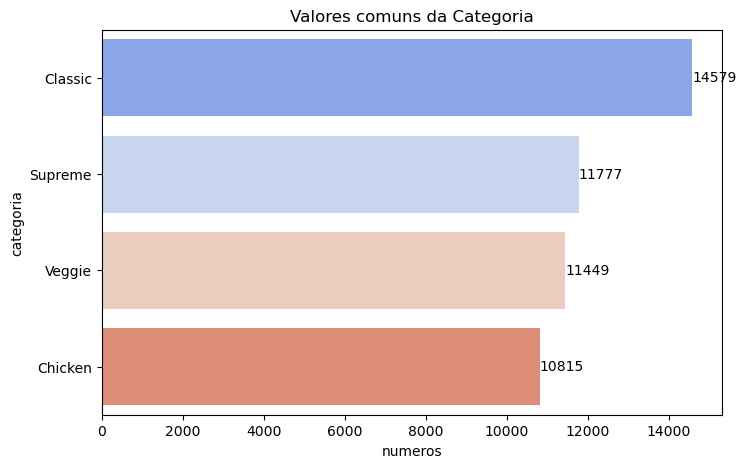

```python
plt.figure(figsize=(8, 5))
category_counts = merged_df['category'].value_counts()
ax = sns.barplot(x=category_counts.values, y=category_counts.index, palette='coolwarm')
for index, value in enumerate(category_counts.values):
    ax.text(value, index, str(value), va='center')


plt.title('Valores comuns da Categoria')
plt.xlabel('numeros')
plt.ylabel('categoria')
plt.show()
```

Fazendo um grafico de Barras com o preço medio por tamanho.

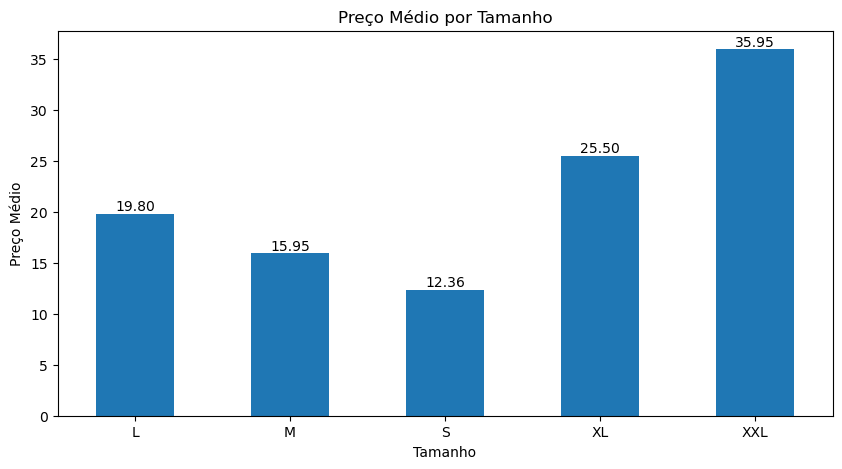

```python
mean_prices = merged_df.groupby('size')['price'].mean()

ax = mean_prices.plot(
    kind='bar',
    figsize=(10, 5),
    title='Preço Médio por Tamanho',
    ylabel='Preço Médio',
    xlabel='Tamanho',
    rot=0
)

for p in ax.patches:
    ax.annotate(
        format(p.get_height(), '.2f'),
        (p.get_x() + p.get_width() / 2., p.get_height()),
        ha='center', va='center',
        xytext=(0, 5),
        textcoords='offset points'
    )
```

```python
grouped = merged_df.groupby(['size', 'pizza_type_id'])['quantity'].sum()

most_ordered = grouped.groupby(level=0).idxmax()
most_ordered_quantities = grouped[most_ordered]

result_df = pd.DataFrame({
    'size': most_ordered.index,
    'most_ordered_pizza': most_ordered.values,
    'quantity': most_ordered_quantities.values
})

print(result_df)
```

```
  size most_ordered_pizza  quantity
0    L      (L, thai_ckn)      1410
1    M   (M, classic_dlx)      1181
2    S      (S, big_meat)      1914
3   XL    (XL, the_greek)       552
4  XXL   (XXL, the_greek)        28
```